# Summary report for Ash Vale

UKMON

2017-07-18

# Summary of activity in 2017

Ash Vale operates 3 cameras.

In 2017 Ash Vale has recorded 1301 individual meteor observations. These observations comprise 342 sporadic meteors and 959 stream meteors. A breakdown by month is shown below.

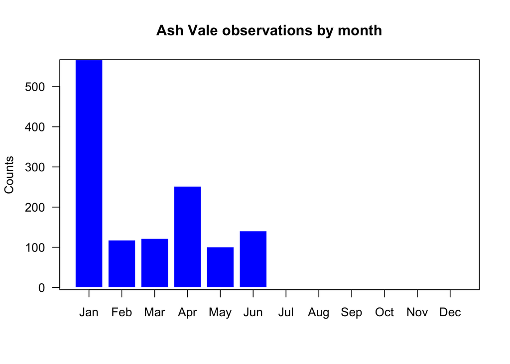

The following shows observation counts by stream for the 20 most frequent showers based on preliminary UFO ANALYSIS classifications:

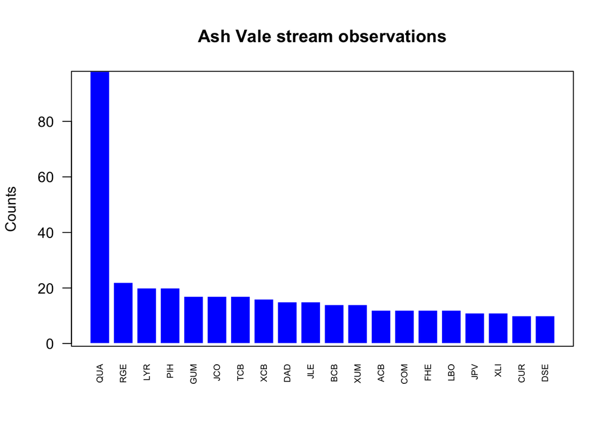

The following table shows which stations are generating matched observations with this station and the number of matches:

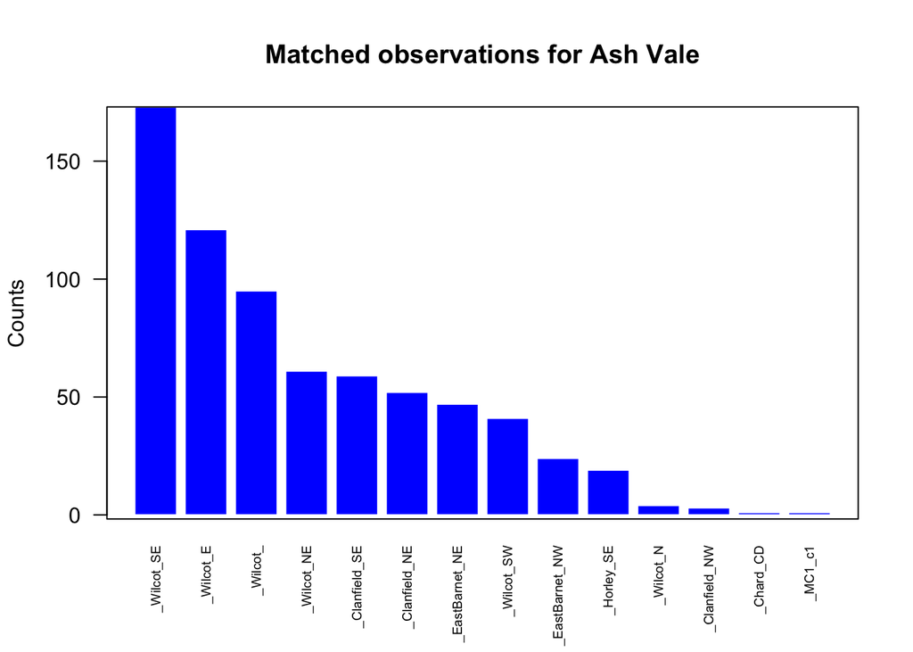

## Fireball activity

(Based on IAU definition of apparrent magnitude of -4.0 of greater)

| Datetime | Magnitude | Duration | Stream |
| --- | --- | --- | --- |
| 2017-04-24 20:44:35 | -5.3 | 2.84 | SPO |
| 2017-01-19 05:33:22 | -5.1 | 0.66 | SPO |
| 2017-03-25 00:03:35 | -5.1 | 1.22 | FHE |
| 2017-04-24 20:44:35 | -5.1 | 0.72 | SPO |
| 2017-01-03 06:49:30 | -5.0 | 0.60 | HYD |
| 2017-01-19 05:33:22 | -4.8 | 0.66 | SPO |
| 2017-04-19 20:45:09 | -4.4 | 22.02 | SPO |
| 2017-04-19 21:51:50 | -4.4 | 1.36 | SPO |
| 2017-04-29 20:52:05 | -4.1 | 0.28 | SPO |

# Observations recorded by Ash Vale, 2012 to 2017

UKMON data for Ash Vale covers the period from 2012 to 2017 and totals 18044 individual meteor observations. These observations comprise 4563 sporadic meteors and 13481 stream meteors.

This section provides a summary of all observations by Ash Vale from 2012 to 2017. A breakdown of the number of observations by year is given in the histogram below.

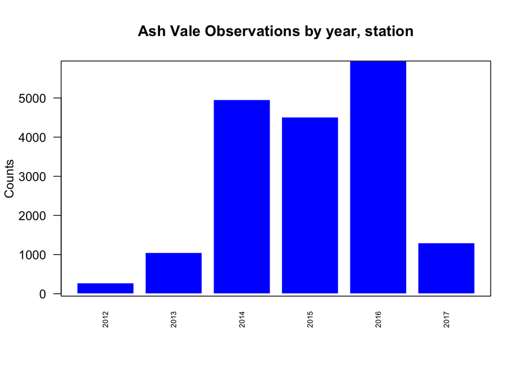

The following graph shows observation counts by stream (preliminary UFO ANALYSIS classification). A detailed breakdown by shower is given in the table at the end of this report.

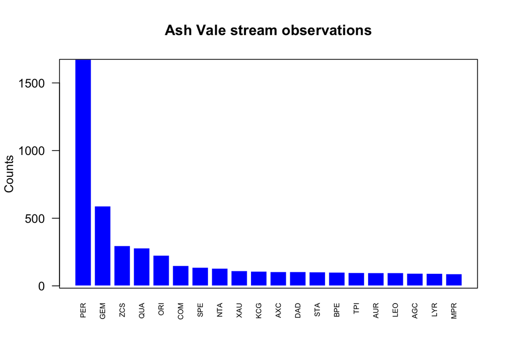

## Fireball activity

Fireballs recorded (Based on IAU definition of apparrent magnitude of -4.0 of greater)

| Datetime | Magnitude | Duration | Stream |
| --- | --- | --- | --- |
| 2014-11-05 19:33:13 | -12.2 | 4.92 | SPO |
| 2016-06-22 21:16:54 | -10.2 | 0.16 | UAN |
| 2016-08-12 00:10:21 | -6.8 | 1.04 | PER |
| 2015-11-12 03:49:11 | -6.7 | 0.18 | SPO |
| 2016-04-26 02:34:02 | -6.7 | 11.10 | SPO |
| 2016-04-20 00:51:06 | -6.6 | 2.52 | SPO |
| 2014-12-15 00:29:30 | -6.4 | 1.60 | GEM |
| 2016-07-14 00:54:20 | -6.3 | 0.86 | SAP |
| 2014-08-07 22:09:21 | -6.0 | 0.68 | OCY |
| 2015-01-30 04:55:15 | -5.9 | 0.74 | RGE |
| 2015-11-21 05:05:06 | -5.8 | 0.50 | DCL |
| 2016-04-26 01:57:19 | -5.7 | 8.06 | SPO |
| 2016-04-14 21:05:31 | -5.6 | 0.20 | AVB |
| 2014-11-02 21:15:34 | -5.5 | 1.26 | PAR |
| 2015-11-28 01:51:30 | -5.5 | 2.12 | STA |
| 2017-04-24 20:44:35 | -5.3 | 2.84 | SPO |
| 2013-07-05 02:37:08 | -5.2 | 0.68 | SPO |
| 2016-07-15 00:35:23 | -5.2 | 1.52 | JBO |
| 2016-08-13 03:10:06 | -5.2 | 0.24 | PER |
| 2014-11-18 21:23:49 | -5.1 | 1.34 | SPO |
| 2015-11-18 21:02:37 | -5.1 | 0.50 | SPO |
| 2015-11-21 00:25:36 | -5.1 | 1.62 | NTA |
| 2017-01-19 05:33:22 | -5.1 | 0.66 | SPO |
| 2017-03-25 00:03:35 | -5.1 | 1.22 | FHE |
| 2017-04-24 20:44:35 | -5.1 | 0.72 | SPO |
| 2015-10-31 22:28:54 | -5.0 | 2.40 | STA |
| 2017-01-03 06:49:30 | -5.0 | 0.60 | HYD |
| 2014-08-09 01:45:07 | -4.9 | 0.26 | JRH |
| 2014-07-31 21:12:24 | -4.8 | 1.14 | SPO |
| 2016-04-20 00:51:06 | -4.8 | 0.30 | SPO |
| 2017-01-19 05:33:22 | -4.8 | 0.66 | SPO |
| 2012-08-10 01:28:03 | -4.7 | 0.32 | SPO |
| 2014-12-14 18:45:29 | -4.7 | 5.84 | SPO |
| 2015-08-16 01:12:43 | -4.7 | 0.80 | PER |
| 2016-07-15 00:35:23 | -4.7 | 1.42 | JBO |
| 2016-08-12 02:41:09 | -4.7 | 0.70 | PER |
| 2013-04-07 04:22:59 | -4.6 | 1.44 | SPO |
| 2014-12-16 02:38:42 | -4.6 | 0.58 | UUM |
| 2015-11-21 00:25:36 | -4.6 | 1.62 | NTA |
| 2016-12-14 03:26:58 | -4.6 | 0.10 | GEM |
| 2013-08-06 02:14:56 | -4.5 | 0.34 | SPO |
| 2015-11-23 02:40:17 | -4.5 | 0.94 | DCL |
| 2015-12-08 22:54:20 | -4.5 | 3.90 | SPO |
| 2016-02-28 01:56:12 | -4.5 | 0.80 | NDL |
| 2016-04-05 21:11:11 | -4.5 | 1.64 | PUM |
| 2016-08-11 23:12:18 | -4.5 | 1.34 | BCA |
| 2014-10-12 02:55:35 | -4.4 | 1.00 | SPO |
| 2015-12-08 22:35:12 | -4.4 | 6.08 | DED |
| 2016-02-03 22:46:00 | -4.4 | 2.68 | SPO |
| 2017-04-19 20:45:09 | -4.4 | 22.02 | SPO |
| 2017-04-19 21:51:50 | -4.4 | 1.36 | SPO |
| 2012-05-17 01:25:58 | -4.3 | 1.04 | SPO |
| 2014-04-07 23:17:00 | -4.3 | 1.74 | SPO |
| 2015-01-31 18:11:39 | -4.3 | 5.28 | SPO |
| 2016-04-08 02:23:32 | -4.3 | 0.24 | SPO |
| 2016-08-12 03:09:56 | -4.3 | 0.78 | PER |
| 2014-03-23 05:19:17 | -4.2 | 0.30 | SPO |
| 2014-08-13 00:25:47 | -4.2 | 0.50 | PER |
| 2016-04-08 20:41:29 | -4.2 | 0.12 | SPO |
| 2016-08-12 02:41:08 | -4.2 | 0.72 | PER |
| 2015-01-19 04:10:25 | -4.1 | 0.40 | PIH |
| 2016-02-03 22:46:01 | -4.1 | 2.48 | SPO |
| 2016-02-27 21:58:28 | -4.1 | 24.86 | NDL |
| 2016-04-17 00:45:48 | -4.1 | 0.24 | SPO |
| 2017-04-29 20:52:05 | -4.1 | 0.28 | SPO |
| 2012-05-28 01:04:53 | -4.0 | 0.62 | SPO |
| 2014-09-01 23:01:58 | -4.0 | 1.46 | AUD |
| 2015-11-12 03:49:11 | -4.0 | 2.14 | NOO |
| 2016-04-05 20:39:03 | -4.0 | 0.58 | SPO |
| 2016-04-05 21:11:11 | -4.0 | 3.82 | SPO |
| 2016-04-23 22:01:26 | -4.0 | 1.10 | SPO |

The following table shows which stations are generating matched observations with this station and the number of matches:

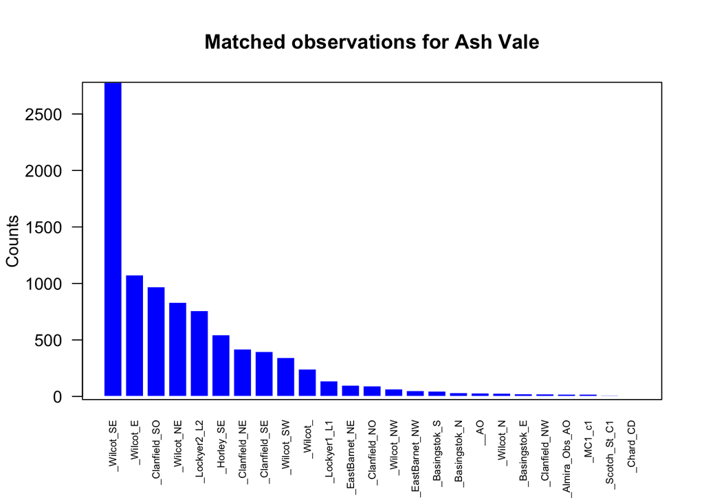

# Detailed counts (including sporadics)

| Shower | Counts |
| --- | --- |
| SPO | 4563 |
| PER | 1674 |
| GEM | 590 |
| ZCS | 297 |
| QUA | 280 |
| ORI | 226 |
| COM | 150 |
| SPE | 137 |
| NTA | 130 |
| XAU | 112 |
| KCG | 108 |
| AXC | 105 |
| DAD | 105 |
| STA | 103 |
| BPE | 101 |
| TPI | 98 |
| AUR | 97 |
| LEO | 97 |
| AGC | 93 |
| LYR | 92 |
| MPR | 89 |
| TRI | 86 |
| NOO | 81 |
| SLY | 81 |
| BCA | 76 |
| EGE | 76 |
| SCS | 75 |
| SIC | 73 |
| URS | 73 |
| AIC | 68 |

[output cut: 382 more lines]